# Лабораторная работа № 13

Презентация

Гайдук Софья Сергеевна

1032253645@rudn.ru

Российский университет дружбы народов

2026-05-01

## Title

# Информация

## Докладчик

- Гайдук Софья Сергеевна
- студент
- Российский университет дружбы народов им. П. Лумумбы
- 1032253645@rudn.ru
- https://github.com/SofiaGayduk/study_2025-2026_os-intro

## Цель работы

Изучить основы программирования в оболочке ОС UNIX. Научится писать более сложные командные файлы с использованием логических управляющих конструкций и циклов.

# Выполнение лабораторной работы

## Задание 1

Используя команды getopts grep, написать командный файл, который анализирует командную строку с ключами ([рис. 1], [рис. 2], [рис. 3], [рис. 4], [рис. 5]).

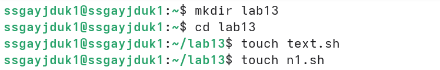

Figure 1: image1

## Задание 1

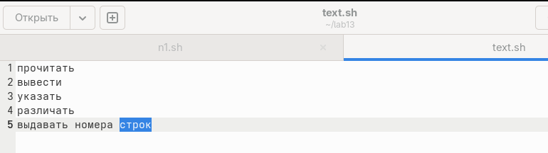

Figure 2: image2

## Задание 1

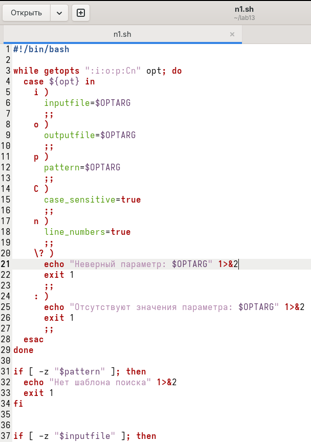

Figure 3: image3

## Задание 1

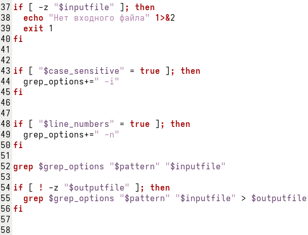

Figure 4: image4

## Задание 1

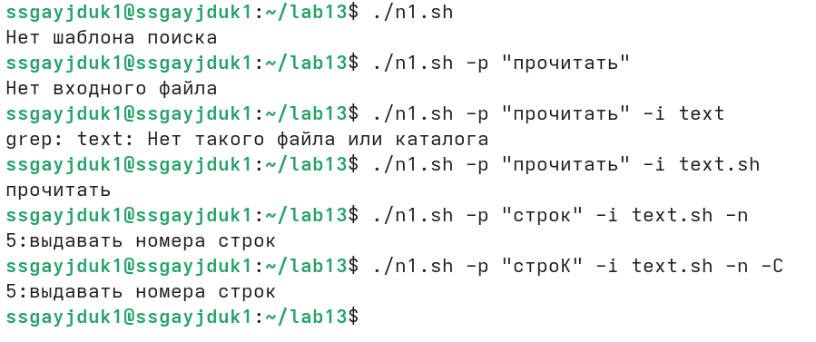

Figure 5: image5

## Задание 2

Написать на языке Си программу, которая вводит число и определяет, является ли оно больше нуля, меньше нуля или равно нулю ([рис. 6], [рис. 7], [рис. 8], [рис. 9], [рис. 10]).

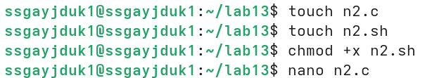

Figure 6: image6

## Задание 2

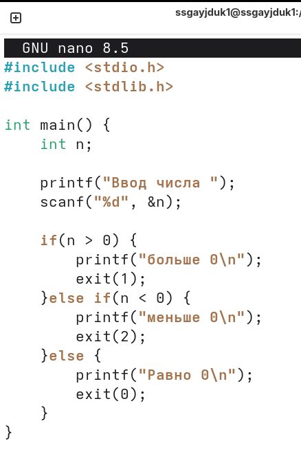

Figure 7: image7

## Задание 2

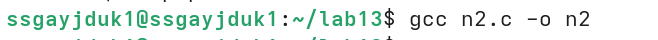

Figure 8: image8

## Задание 2

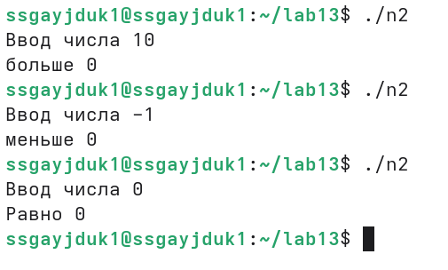

Figure 9: image9

## Задание 2

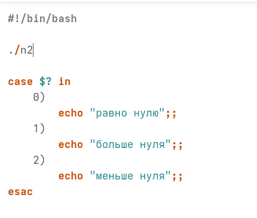

Figure 10: image10

## Задание 2

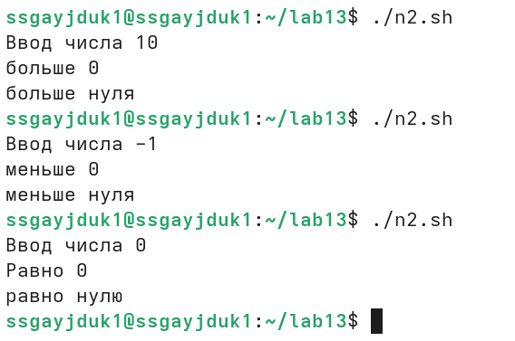

Figure 11: image11

## Задание 3

Написать командный файл, создающий указанное число файлов, пронумерованных последовательно от 1 до N [рис. 12], [рис. 13])

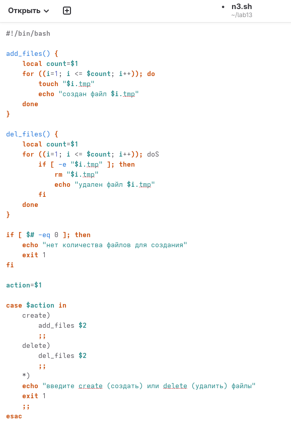

Figure 12: image12

## Задание 3

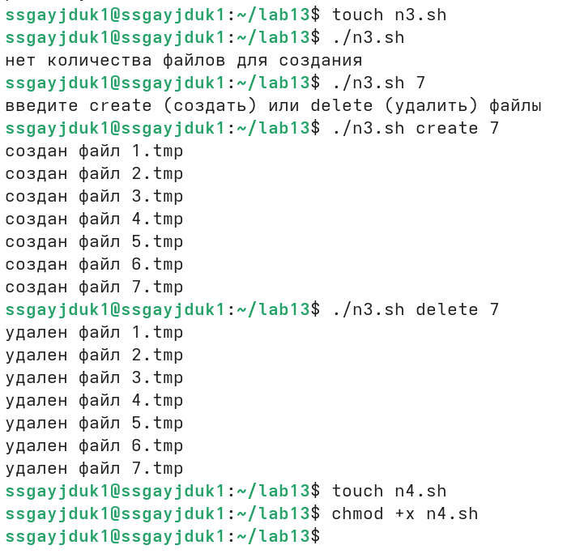

Figure 13: image13

## Задание 4

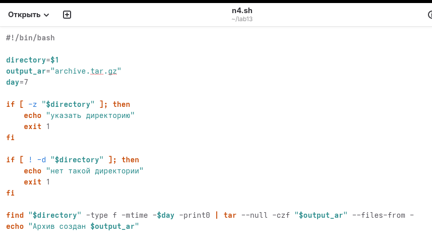

Figure 14: image14

## Задание 4

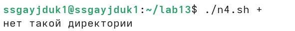

Figure 15: image15

## Задание 4

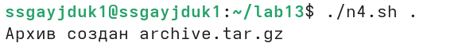

Figure 16: image16

## Задание 4

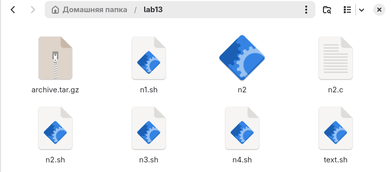

Figure 17: image17

# Выводы

Мы изучили основы программирования в оболочке ОС UNIX. Научились писать более сложные командные файлы с использованием логических управляющих конструкций и циклов.

# Список литературы

1.Kulyabov. Лабораторная работа № 13. Программирование в командном процессоре ОС UNIX. Ветвления и циклы. RUDN